# Developing Data Products Project: Draw random Polygons

06-11-2020

## Project description

- The `Draw random Polygons` project is created for final assignment of Developing Data Products Course.
- The project utilizes `shinyApp` library and is hosted at `shinyapps.io` servers.
- The web address of the current app is: https://igivis7.shinyapps.io/proj03_poly_draw/
- The source code can be found here: https://github.com/igivis7/Proj03_Poly_Draw
- This simple app draws random polygons and the main goal of such a ridiculous app is to test shiny app development and attempt to implement an Update button.
- Some simple instructions to run the app are included to the app itself.

## Main elements of the ui.R file

The `ui.R` main elements (elements except of text and title) are: `sliderInput()` to implement a slide that can control number of vertices, `actionButton()` for including a button for showing polygons and update the plot, and `plotOutput()` to show outcome plot.

The following code shows only main elements of the `ui.R` file:

```r
shinyUI(fluidPage(sidebarLayout(
    #asdasdasd
    sidebarPanel(
        sliderInput("sliderNofPoly",
            "What number of a polygon vertices should be?",
            3, 15, value = 3),
        actionButton("b_upd","Start Plotting Polygons and Update")  ),
    mainPanel( plotOutput("mymap"), )
            )))
```

## Main elements of the server.R file

- `observeEvent(input$b_upd,{})` includes *reactive* calculations of polygons coordinates according to slider value `input$sliderNofPoly`, and drawing them to a plot `output$mymap`. The `observeEvent` attaches calculation to the button event.
- the 2nd string from the end consists of `output$mymap` element for presenting a plot before the button is pressed.
- A simplified code `server.R` file is show here:

```r
shinyServer( function(input, output, session) {
 observeEvent(input$b_upd, {
  lat_val <- reactive({rnorm(input$sliderNofPoly)/5*180})
  lng_val <- reactive({rnorm(input$sliderNofPoly)/5*360})
  output$mymap <- renderPlot({
    plot(lat_val(), lng_val(), type = "n", xlab="X", ylab="Y")
    polygon(lat_val(), lng_val(), col = "gray", border = "red")   }) })
 output$mymap <- renderPlot({ plot(1,1, xlab="X", ylab="Y") })    })
```

## Basics of a random polygon drawing

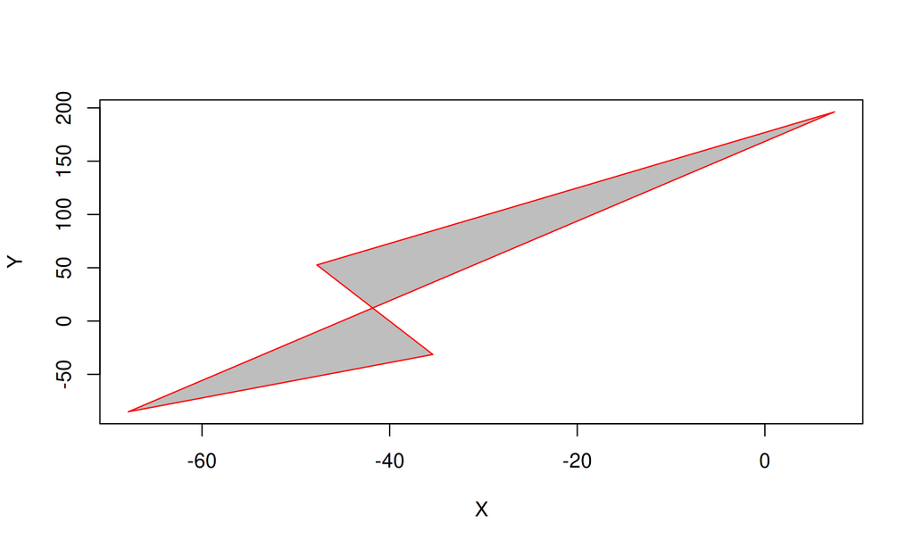

```r
lat_val <- rnorm(n=4) / 5 * 180
lng_val <- rnorm(n=4) / 5 * 360
plot(lat_val, lng_val, type = "n", xlab="X", ylab="Y")
polygon(lat_val, lng_val, col = "gray", border = "red")
```